# final exam

# wish i can pass!!

(1.a) Give two simple functions to evaluate the sum of each column for a matrix. (Do not use for(. . . ))

(1.b) What is the function that can be used for comparion of computation time?

A: benchmark()

```r
x <- matrix(c(-0.45 , 0.77, 0.16, 1.22, 1.75, 0.24,
              0.27, 1.74, 0.07, -0.87, -0.90, 1.07,
              -0.06, 0.33, -0.06, 0.09, 0.10, -0.04), 3, 6, byrow = TRUE)
absolute<-function(x){
  abs(x-mean(x))/length(x)
}
x2<-apply(x,1,absolute)
apply(x2,2,sum)
```

```
## [1] 0.6316667 0.7966667 0.1133333
```

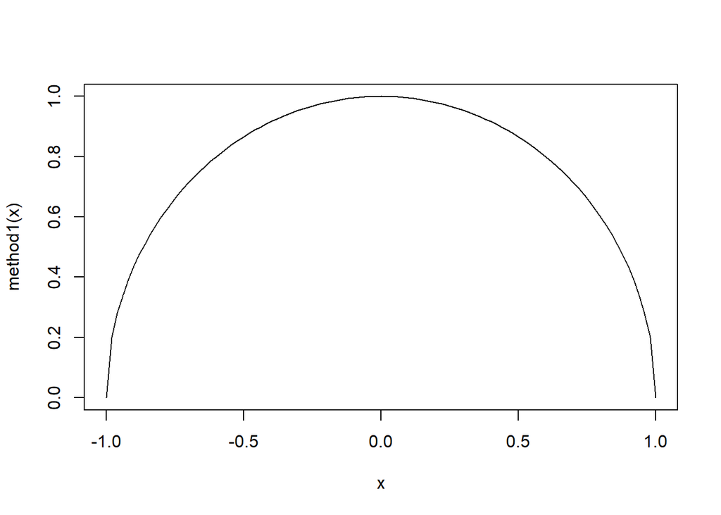

```r
method1<-function(x){
  (1-x^2)^(1/2)
}
method2<-function(x){
  -((1-x^2)^(1/2))
}
curve(method1,-1,1)
```

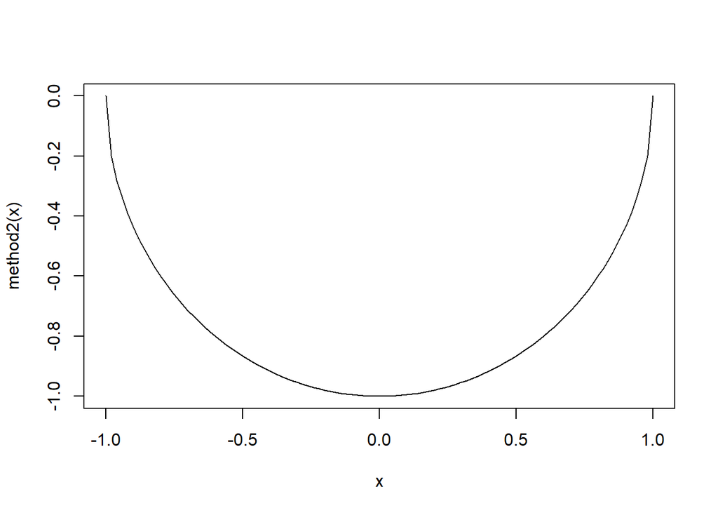

```r
curve(method2,-1,1)
```

5. Use the dataset iris. Write a code to draw the plot:

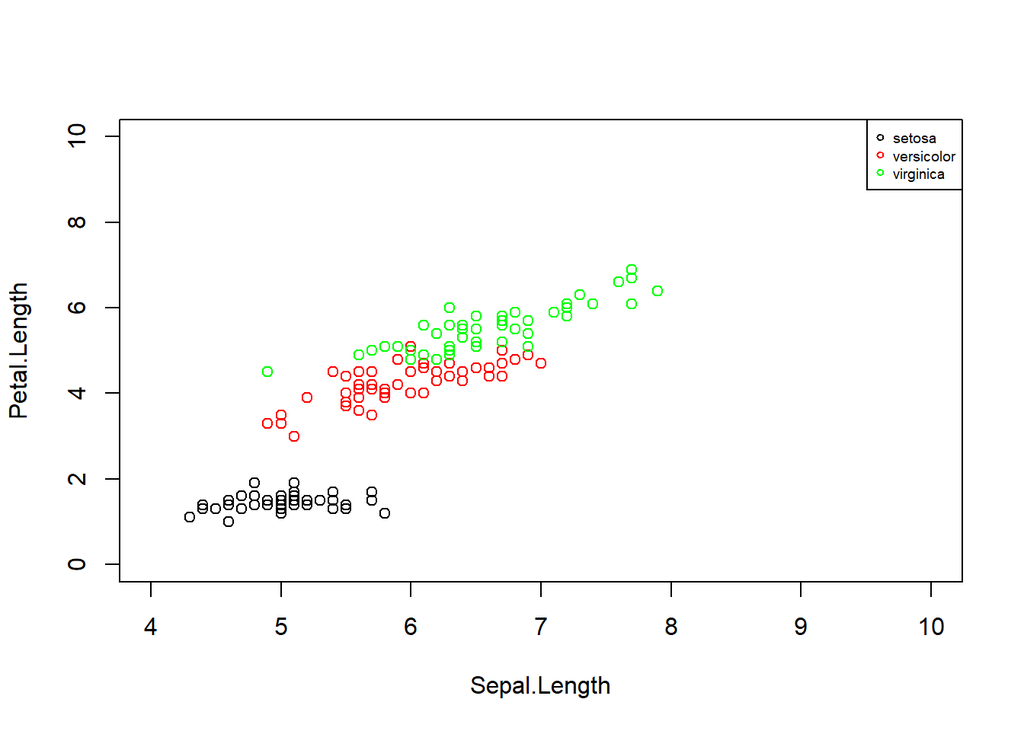

```r
data.1e<-iris
setosa<-data.1e[data.1e$Species=='setosa',]
versicolor<-data.1e[data.1e$Species=='versicolor',]
virginica<-data.1e[data.1e$Species=='virginica',]
plot(setosa$Sepal.Length,setosa$Petal.Length,col='black',xlim = c(4,10),
     ylim = c(0,10),xlab='Sepal.Length',ylab = 'Petal.Length')
points(versicolor$Sepal.Length,versicolor$Petal.Length,col='red')
points(virginica$Sepal.Length,virginica$Petal.Length,col='green')
legend('topright',c('setosa','versicolor','virginica'),pch=1,col=c('black','red','green'),cex=0.6)
```

2. (30%) Download the package “titanic” and library(“titanic”). Use data(titanic_train) to the following questions:

```r
library('titanic')
data.2<-titanic_train
#a
colnames(data.2)
```

```
##  [1] "PassengerId" "Survived"    "Pclass"      "Name"        "Sex"
##  [6] "Age"         "SibSp"       "Parch"       "Ticket"      "Fare"
## [11] "Cabin"       "Embarked"
```

```r
#b
length(data.2$PassengerId)
```

```
## [1] 891
```

```r
length(data.2[data.2$Survived==1,]$PassengerId)
```

```
## [1] 342
```

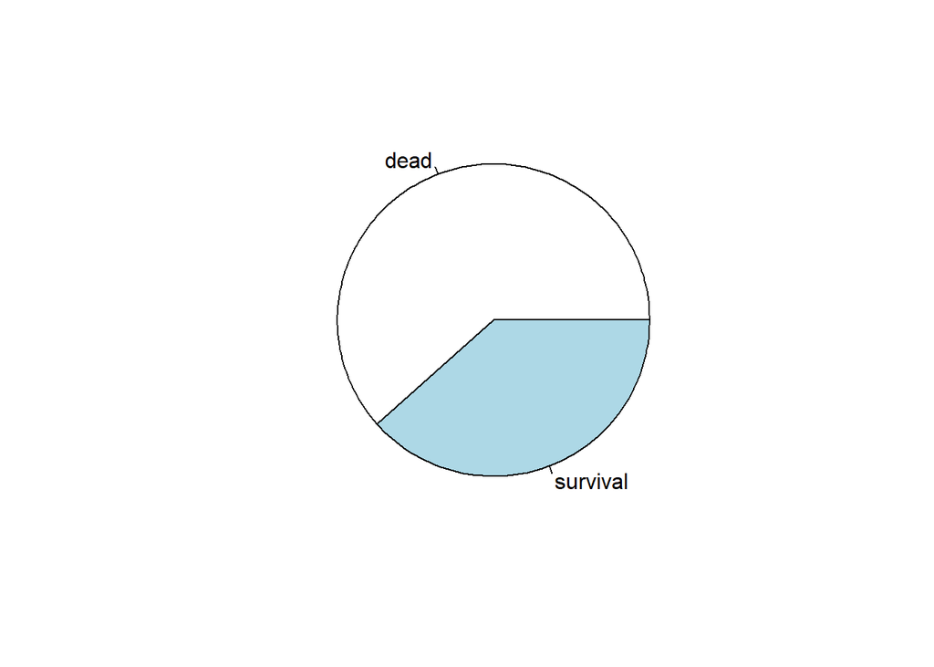

```r
#c
pie(table(data.2$Survived),labels = c('dead','survival'))
```

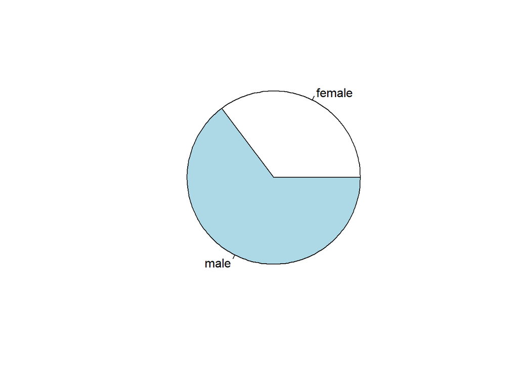

```r
pie(table(data.2$Sex))
```

```r
#d
survived<-data.2[data.2$Survived==1,]
dead<-data.2[data.2$Survived==0,]
table(survived$Sex)/length(survived$Sex)
```

```
##
##    female      male
## 0.6812865 0.3187135
```

```r
table(dead$Sex)/length(dead$Sex)
```

```
##
##   female     male
## 0.147541 0.852459
```

```r
dummy<-function(x){
  x<-as.character(x)
  all_vv<-unique(x)
  newdata<-c()
  for (r in x){
    dummy_initial<-rep(0,length(all_vv))
    dummy_initial[grep(r,all_vv)[1]]<-1
    newdata<-c(newdata,dummy_initial)
  }
  final<-matrix(newdata,length(x),length(all_vv),byrow = T)
  colnames(final)<-all_vv
  final
}

#f
colSums(dummy(titanic_train$Pclass))
```

```
##   3   1   2
## 491 216 184
```

```r
colSums(dummy(titanic_train$Sex))
```

```
##   male female
##    577    314
```

3. (15%) Let x <- seq(-1.5, 1.5, 0.01) and y <- seq(-1.5, 1.5, 0.01).

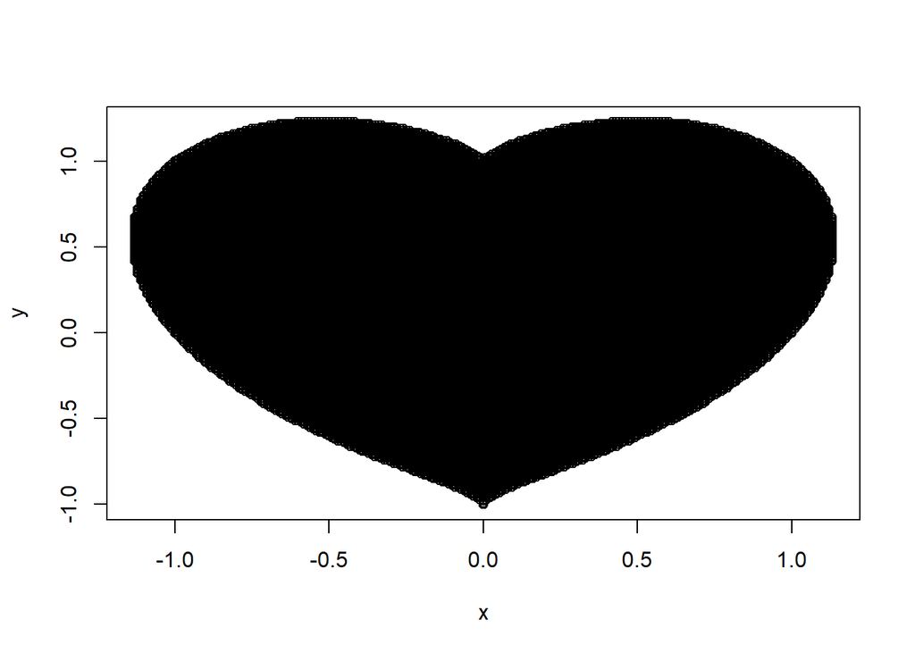

```r
x <- seq(-1.5, 1.5, 0.01)
y <- seq(-1.5, 1.5, 0.01)
point<-c()
for (t in 1:length(x)){
  for (n in 1:length(y)){
    x1<-x[t]
    y1<-y[n]
    if(x1^2*y1^3-((x1^2+y1^2-1)^3)>=0){
      point<-c(point,c(x1,y1))
    }
  }
}
answer<-matrix(point,length(point)/2,2,byrow = T)
plot(answer[,1],answer[,2],xlab = 'x',ylab = 'y')
```

```r
#heart
```

4. (30%) Download the package “nlme” and library(nlme). Begin with the data: data(Fatigue). There are three columns, which are “Path”, “cycles”, and “relLength”. Path means the ID number of a unit, cycles means the measurement time point, and relLength means the crack length over cycles. Use the Fatigue data to the following questions:

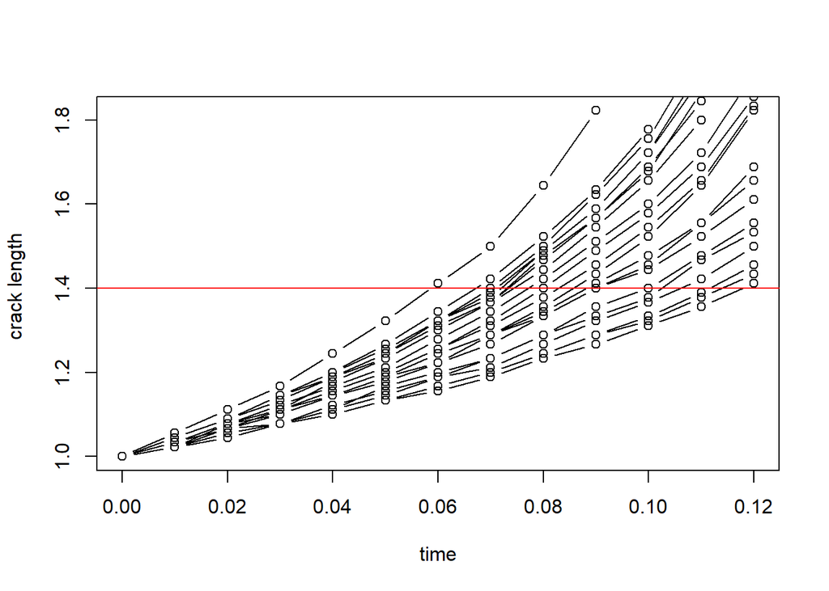

```r
library('nlme')
data.4<-Fatigue
#a
number<-length(unique(Fatigue$Path))
#b
path<-Fatigue[Fatigue$Path==1,]
plot(path$cycles,path$relLength, type =
       "b",xlab = 'time',ylab='crack length ',xlim = c(0,0.12))
for (q in 2:number){
  points(Fatigue[Fatigue$Path==q,]$cycles,
         Fatigue[Fatigue$Path==q,]$relLength, type =
           "b")
}
#c
abline(h=1.4,col='red')
```

```r
#d
answer2<-c()
for (y in 1:number){
  p<-Fatigue[Fatigue$Path==y,]
  n<-length(p[p$relLength>1.4,]$relLength)
  answer2<-c(answer2,n)
}
length(answer2)
```

```
## [1] 21
```

```r
#e
all_a<-c()
for (k in 1:number){
  p<-Fatigue[Fatigue$Path==k,]
  p$relLength<-log(p$relLength)
  fit<-lm(relLength~cycles -1,data=p)
  all_a<-c(all_a,fit$coefficients)
}
all_a
```

```
##   cycles   cycles   cycles   cycles   cycles   cycles   cycles   cycles
## 6.064145 5.273203 5.372019 5.208597 5.172207 5.023958 4.974296 4.806996
##   cycles   cycles   cycles   cycles   cycles   cycles   cycles   cycles
## 4.710769 4.506916 4.359618 4.220225 3.831828 3.742037 3.855037 3.336587
##   cycles   cycles   cycles   cycles   cycles
## 3.278013 3.102366 2.856988 2.802117 2.678800
```

```r
mean(all_a)
```

```
## [1] 4.24651
```

```r
#e
t.test(all_a, alternative = "two.sided",
       mu = 5, conf.level = 0.95)
```

```
##
##  One Sample t-test
##
## data:  all_a
## t = -3.5166, df = 20, p-value = 0.00217
## alternative hypothesis: true mean is not equal to 5
## 95 percent confidence interval:
##  3.799564 4.693457
## sample estimates:
## mean of x
##   4.24651
```